# Summer Internship

Navin Ramanan

6/01/2022

##Setup

```
## Cortex: Running DESeq2 for Diet(Control vs Supplemented) with APP=APP, Age=9:padj < 0.05 and 0.10
```

```
## Cortex: APP9Control vs APP9Supplemented
```

```
## resultsNames:
```

```
##  [1] "Intercept"
##  [2] "group_APP12Supplemented_vs_APP12Control"
##  [3] "group_APP3Control_vs_APP12Control"
##  [4] "group_APP3Supplemented_vs_APP12Control"
##  [5] "group_APP6Control_vs_APP12Control"
##  [6] "group_APP6Supplemented_vs_APP12Control"
##  [7] "group_APP9Control_vs_APP12Control"
##  [8] "group_APP9Supplemented_vs_APP12Control"
##  [9] "group_WT12Control_vs_APP12Control"
## [10] "group_WT12Supplemented_vs_APP12Control"
## [11] "group_WT3Control_vs_APP12Control"
## [12] "group_WT3Supplemented_vs_APP12Control"
## [13] "group_WT6Control_vs_APP12Control"
## [14] "group_WT6Supplemented_vs_APP12Control"
## [15] "group_WT9Control_vs_APP12Control"
## [16] "group_WT9Supplemented_vs_APP12Control"
## [1] "group"            "APP9Control"      "APP9Supplemented"
##
## out of 34880 with nonzero total read count
## adjusted p-value < 0.1
## LFC > 0 (up)       : 2, 0.0057%
## LFC < 0 (down)     : 0, 0%
## outliers [1]       : 101, 0.29%
## low counts [2]     : 0, 0%
## (mean count < 0)
## [1] see 'cooksCutoff' argument of ?results
## [2] see 'independentFiltering' argument of ?results
```

```
## log2 fold change (MLE): group APP9Control vs APP9Supplemented
## Wald test p-value: group APP9Control vs APP9Supplemented
## DataFrame with 10 rows and 6 columns
##                     baseMean log2FoldChange     lfcSE      stat      pvalue
##                    <numeric>      <numeric> <numeric> <numeric>   <numeric>
## ENSMUSG00000040380  59.19853       3.318491 0.5084565   6.52660 6.72805e-11
## ENSMUSG00000044681   8.84061       5.045775 1.0631563   4.74603 2.07444e-06
## ENSMUSG00000020428  11.38069       5.559961 1.3050987   4.26018 2.04258e-05
## ENSMUSG00000091509 181.42617       0.772410 0.1859350   4.15419 3.26437e-05
## ENSMUSG00000105945  33.60277       0.967651 0.2485834   3.89266 9.91500e-05
## ENSMUSG00000028683 881.78006       0.342267 0.0876536   3.90477 9.43159e-05
## ENSMUSG00000089975  16.00037      -1.344137 0.3541523  -3.79536 1.47427e-04
## ENSMUSG00002076103  36.96512       0.990990 0.2702484   3.66696 2.45452e-04
## ENSMUSG00000110057  11.86817       1.700956 0.4648293   3.65931 2.52893e-04
## ENSMUSG00000032591   8.90347      -1.851648 0.5185550  -3.57078 3.55915e-04
##                           padj
##                      <numeric>
## ENSMUSG00000040380 2.33995e-06
## ENSMUSG00000044681 3.60735e-02
## ENSMUSG00000020428 2.36797e-01
## ENSMUSG00000091509 2.83828e-01
## ENSMUSG00000105945 5.74723e-01
## ENSMUSG00000028683 5.74723e-01
## ENSMUSG00000089975 7.32478e-01
## ENSMUSG00002076103 7.73648e-01
## ENSMUSG00000110057 7.73648e-01
## ENSMUSG00000032591 7.73648e-01
```

```
## log2 fold change (MLE): group APP9Control vs APP9Supplemented
## Wald test p-value: group APP9Control vs APP9Supplemented
## DataFrame with 34880 rows and 6 columns
##                       baseMean log2FoldChange     lfcSE      stat      pvalue
##                      <numeric>      <numeric> <numeric> <numeric>   <numeric>
## ENSMUSG00000040380    59.19853       3.318491  0.508457   6.52660 6.72805e-11
## ENSMUSG00000044681     8.84061       5.045775  1.063156   4.74603 2.07444e-06
## ENSMUSG00000020428    11.38069       5.559961  1.305099   4.26018 2.04258e-05
## ENSMUSG00000091509   181.42617       0.772410  0.185935   4.15419 3.26437e-05
## ENSMUSG00000105945    33.60277       0.967651  0.248583   3.89266 9.91500e-05
## ...                        ...            ...       ...       ...         ...
## ENSMUSG00000109212    0.769426       0.000000  8.245409   0.00000          NA
## ENSMUSG00000054134   40.269651       1.021038  0.754740   1.35283          NA
## ENSMUSG00000024028    0.789155       0.000000  8.245409   0.00000          NA
## ENSMUSG00000061808 1664.189531       0.843561  0.828624   1.01803          NA
## ENSMUSG00000037451    1.547250      21.985519  8.216583   2.67575          NA
##                           padj
##                      <numeric>
## ENSMUSG00000040380 2.33995e-06
## ENSMUSG00000044681 3.60735e-02
## ENSMUSG00000020428 2.36797e-01
## ENSMUSG00000091509 2.83828e-01
## ENSMUSG00000105945 5.74723e-01
## ...                        ...
## ENSMUSG00000109212          NA
## ENSMUSG00000054134          NA
## ENSMUSG00000024028          NA
## ENSMUSG00000061808          NA
## ENSMUSG00000037451          NA
```

```
## class: DESeqDataSet
## dim: 34880 96
## metadata(1): version
## assays(4): counts mu H cooks
## rownames(34880): ENSMUSG00000102628 ENSMUSG00000097426 ...
##   ENSMUSG00000095041 ENSMUSG00000095742
## rowData names(78): baseMean baseVar ... deviance maxCooks
## colnames(96): 102 103 ... 95 96
## colData names(6): Sex Diet ... group sizeFactor
```

```
## Cortex DESeq2 result is saved in file: 'Cortex_deseq_results_Diet_APP_9.csv'
```

```
## Cortex DESeq2 normalized counts is saved in file: 'Cortex_deseq_norm_counts_Diet_APP_9.csv'
```

```
## Cortex DESeq2 result with Gene names (mgi_symbols) is saved in file: 'Cortex_deseq_results_with_genename_Diet_APP_9.csv'
```

```
## [1] 34880
```

```
## [1] 2
```

```
## Cortex DESeq2 result after padj (0.05) filtering is saved in file: 'Cortex_deseq_results_Diet_APP_9_padj_05_filtered.csv'
```

```
## Number of DE genes significant at padj < 0.05 for Cortex:APP9Control vs APP9Supplemented: 2
```

```
## Number of DE genes discarded after padj threshold 0.05 filtering for Cortex:APP9Control vs APP9Supplemented: 34878
```

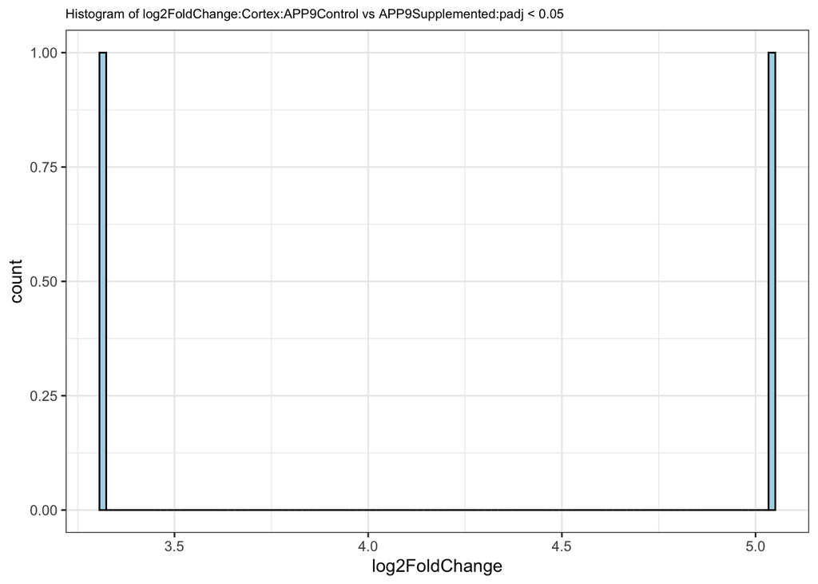

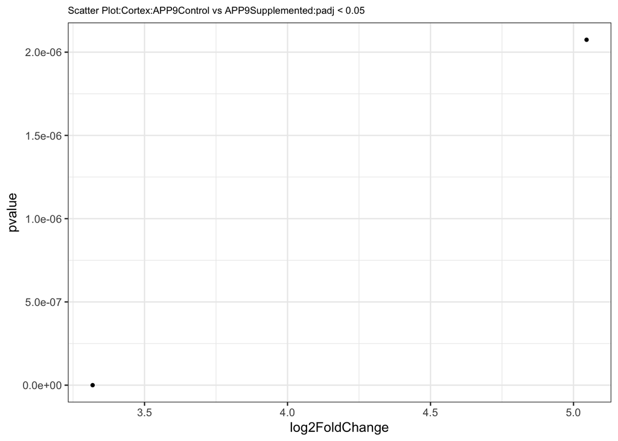

```
## [1] 34880
```

```
## [1] 2
```

```
## Cortex DESeq2 result after padj (0.1) filtering is saved in file: 'Cortex_deseq_results_Diet_APP_9_padj_1_filtered.csv'
```

```
## Number of DE genes significant at padj < 0.1 for Cortex:APP9Control vs APP9Supplemented: 2
```

```
## Number of DE genes discarded after padj threshold 0.1 filtering for Cortex:APP9Control vs APP9Supplemented: 34878
```

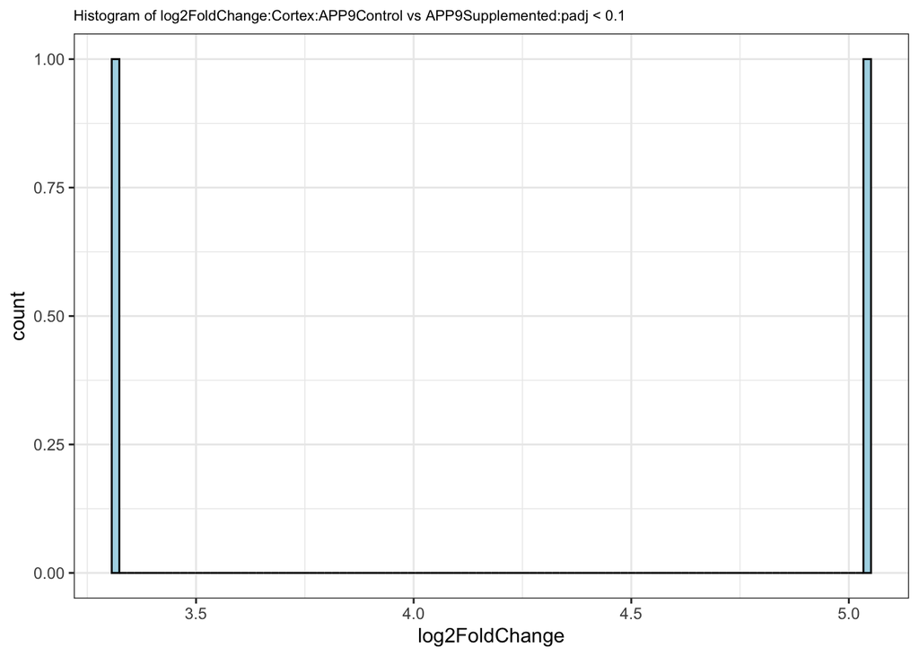

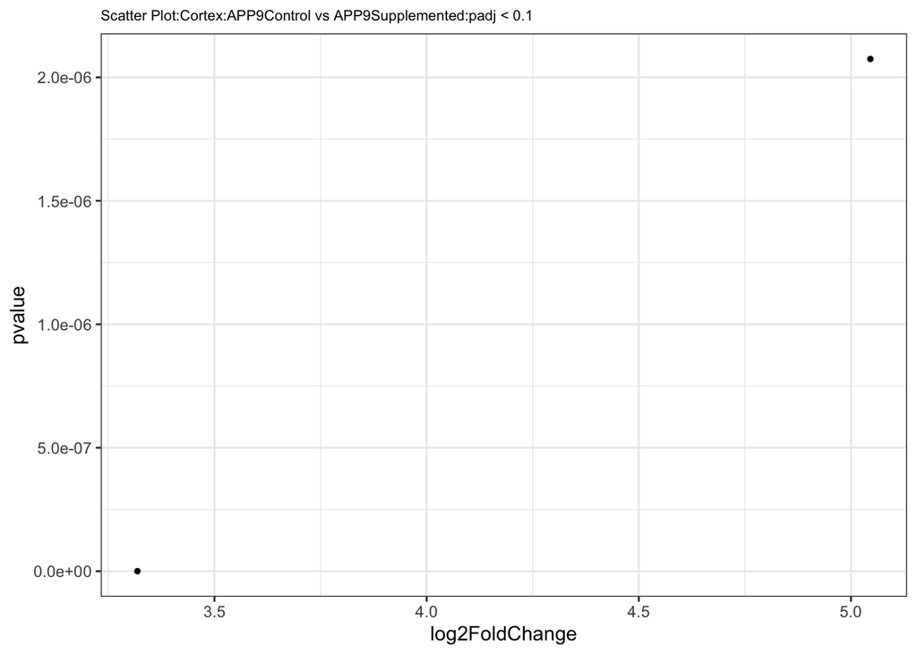

6. Cortex: Enhanced Volcano Plot

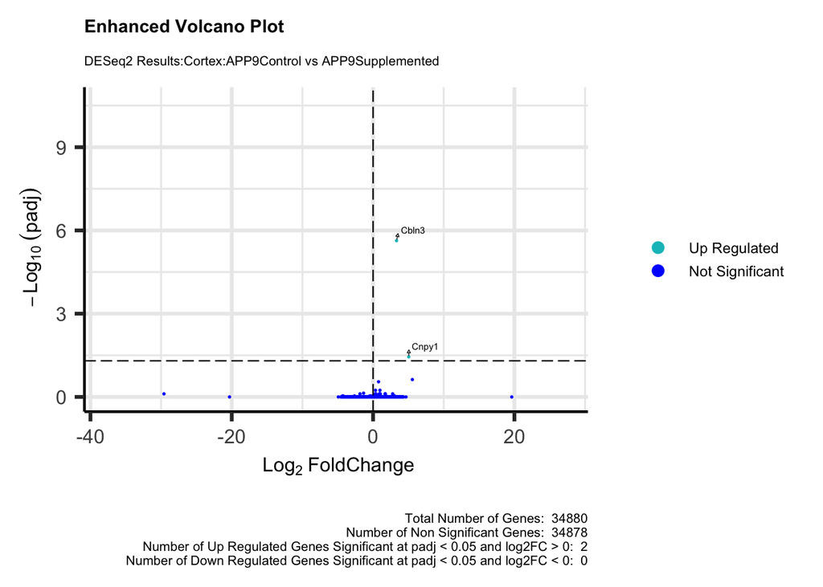

7. Cortex: Heatmap

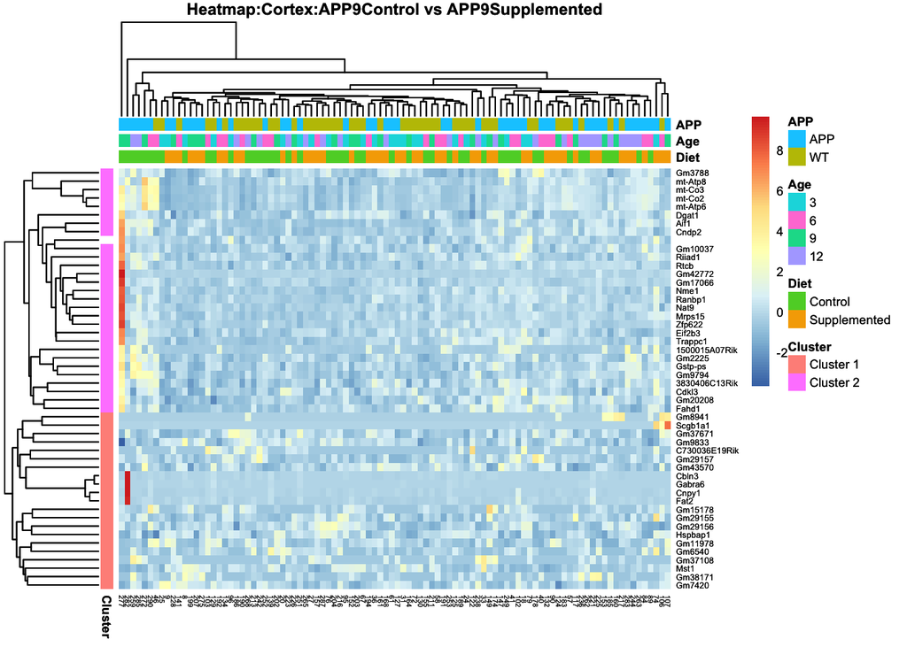

```
## Hippocampus: Running DESeq2 for Diet(Control vs Supplemented) with APP=APP, Age=9:padj < 0.05 and 0.10
```

```
## Hippocampus: APP9Control vs APP9Supplemented
```

```
## resultsNames:
```

```
##  [1] "Intercept"
##  [2] "group_APP12Supplemented_vs_APP12Control"
##  [3] "group_APP3Control_vs_APP12Control"
##  [4] "group_APP3Supplemented_vs_APP12Control"
##  [5] "group_APP6Control_vs_APP12Control"
##  [6] "group_APP6Supplemented_vs_APP12Control"
##  [7] "group_APP9Control_vs_APP12Control"
##  [8] "group_APP9Supplemented_vs_APP12Control"
##  [9] "group_WT12Control_vs_APP12Control"
## [10] "group_WT12Supplemented_vs_APP12Control"
## [11] "group_WT3Control_vs_APP12Control"
## [12] "group_WT3Supplemented_vs_APP12Control"
## [13] "group_WT6Control_vs_APP12Control"
## [14] "group_WT6Supplemented_vs_APP12Control"
## [15] "group_WT9Control_vs_APP12Control"
## [16] "group_WT9Supplemented_vs_APP12Control"
## [1] "group"            "APP9Control"      "APP9Supplemented"
##
## out of 33271 with nonzero total read count
## adjusted p-value < 0.1
## LFC > 0 (up)       : 0, 0%
## LFC < 0 (down)     : 0, 0%
## outliers [1]       : 77, 0.23%
## low counts [2]     : 0, 0%
## (mean count < 0)
## [1] see 'cooksCutoff' argument of ?results
## [2] see 'independentFiltering' argument of ?results
```

```
## log2 fold change (MLE): group APP9Control vs APP9Supplemented
## Wald test p-value: group APP9Control vs APP9Supplemented
## DataFrame with 10 rows and 6 columns
##                       baseMean log2FoldChange     lfcSE       stat    pvalue
##                      <numeric>      <numeric> <numeric>  <numeric> <numeric>
## ENSMUSG00000102628    4.933073     -0.2570243  0.667239 -0.3852055  0.700085
## ENSMUSG00000086053    1.288311      1.7056157  1.665473  1.0241027  0.305787
## ENSMUSG00000102135    0.260071      2.1942574  4.962226  0.4421922  0.658350
## ENSMUSG00000100764    7.786530      0.3007229  0.674458  0.4458733  0.655689
## ENSMUSG00000100635   10.643846      0.8107276  0.969809  0.8359666  0.403174
## ENSMUSG00000100480   40.881695      0.0691727  0.334334  0.2068968  0.836090
## ENSMUSG00000100025    9.761216     -0.4121790  0.494998 -0.8326888  0.405020
## ENSMUSG00000051285 7467.607010      0.0102401  0.225279  0.0454551  0.963745
## ENSMUSG00000098201    0.329138      0.6146887  6.801198  0.0903795  0.927986
## ENSMUSG00000103509   49.977391     -0.4414351  0.325106 -1.3578187  0.174521
##                         padj
##                    <numeric>
## ENSMUSG00000102628         1
## ENSMUSG00000086053         1
## ENSMUSG00000102135         1
## ENSMUSG00000100764         1
## ENSMUSG00000100635         1
## ENSMUSG00000100480         1
## ENSMUSG00000100025         1
## ENSMUSG00000051285         1
## ENSMUSG00000098201         1
## ENSMUSG00000103509         1
```

```
## log2 fold change (MLE): group APP9Control vs APP9Supplemented
## Wald test p-value: group APP9Control vs APP9Supplemented
## DataFrame with 33271 rows and 6 columns
##                       baseMean log2FoldChange     lfcSE       stat    pvalue
##                      <numeric>      <numeric> <numeric>  <numeric> <numeric>
## ENSMUSG00000102628    4.933073      -0.257024  0.667239  -0.385205  0.700085
## ENSMUSG00000086053    1.288311       1.705616  1.665473   1.024103  0.305787
## ENSMUSG00000102135    0.260071       2.194257  4.962226   0.442192  0.658350
## ENSMUSG00000100764    7.786530       0.300723  0.674458   0.445873  0.655689
## ENSMUSG00000100635   10.643846       0.810728  0.969809   0.835967  0.403174
## ...                        ...            ...       ...        ...       ...
## ENSMUSG00000068196   434.29152      0.2204786   1.19477  0.1845365        NA
## ENSMUSG00000053375     1.58633      1.1530357   3.12900  0.3684992        NA
## ENSMUSG00000023122    38.89638      0.0651168   2.46964  0.0263670        NA
## ENSMUSG00000023943    18.46229      0.2311560   2.59489  0.0890811        NA
## ENSMUSG00000061808 34756.71162     -0.2417486   1.53464 -0.1575283        NA
##                         padj
##                    <numeric>
## ENSMUSG00000102628         1
## ENSMUSG00000086053         1
## ENSMUSG00000102135         1
## ENSMUSG00000100764         1
## ENSMUSG00000100635         1
## ...                      ...
## ENSMUSG00000068196        NA
## ENSMUSG00000053375        NA
## ENSMUSG00000023122        NA
## ENSMUSG00000023943        NA
## ENSMUSG00000061808        NA
```

```
## class: DESeqDataSet
## dim: 33271 96
## metadata(1): version
## assays(4): counts mu H cooks
## rownames(33271): ENSMUSG00000102628 ENSMUSG00000086053 ...
##   ENSMUSG00000095041 ENSMUSG00000095742
## rowData names(78): baseMean baseVar ... deviance maxCooks
## colnames(96): 102 103 ... 95 96
## colData names(6): Sex Diet ... group sizeFactor
```

```
## Hippocampus DESeq2 result is saved in file: 'Hippocampus_deseq_results_Diet_APP_9.csv'
```

```
## Hippocampus DESeq2 normalized counts is saved in file: 'Hippocampus_deseq_norm_counts_Diet_APP_9.csv'
```

```
## Hippocampus DESeq2 result with Gene names (mgi_symbols) is saved in file: 'Hippocampus_deseq_results_with_genename_Diet_APP_9.csv'
```

```
## Hippocampus DESeq2 result after padj (0.05) filtering is saved in file: 'Hippocampus_deseq_results_Diet_APP_9_padj_05_filtered.csv'
```

```
## Number of DE genes significant at padj < 0.05 for Hippocampus:APP9Control vs APP9Supplemented: 0
```

```
## Number of DE genes discarded after padj threshold < 0.05 filtering for Hippocampus:APP9Control vs APP9Supplemented: 33271
```

[figure not shown]

[figure not shown]

```
## Hippocampus DESeq2 result after padj (0.1) filtering is saved in file: 'Hippocampus_deseq_results_Diet_APP_9_padj_1_filtered.csv'
```

```
## Number of DE genes significant at padj < 0.1 for Hippocampus:APP9Control vs APP9Supplemented: 0
```

```
## Number of DE genes discarded after padj threshold < 0.1 filtering for Hippocampus:APP9Control vs APP9Supplemented: 33271
```

[figure not shown]

[figure not shown]

9. Hippocampus: Enhanced Volcano Plot

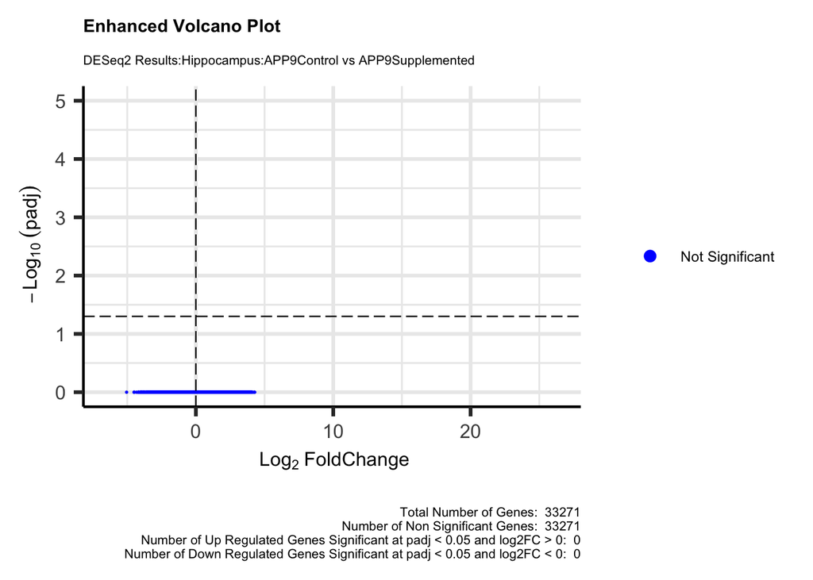

10. Hippocampus: Heatmap

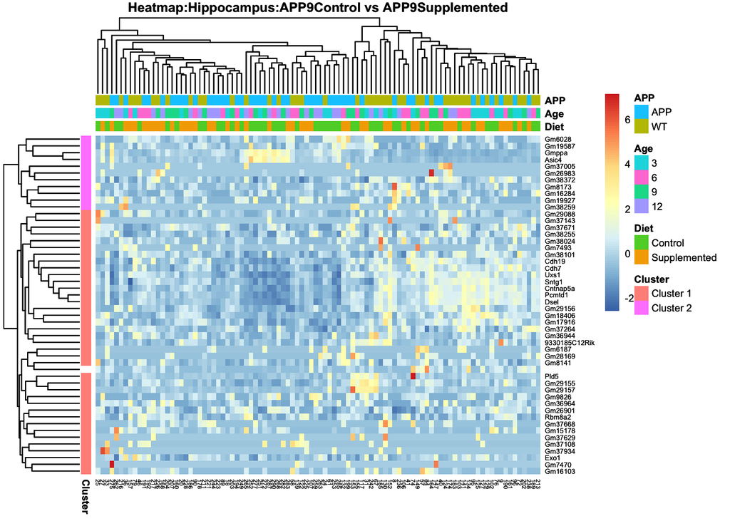

11. GSEA:Running fgsea

Perform a GSEA using a ranked list log2FoldChange values for all genes discovered in the DESeq2 results against the M2 Canonical Pathways gene set collection. Convert gene identifiers in the results to the appropriate matching format found in the M2 gene sets. fgsea expects a named vector of gene level statistics and the gene sets in the form of a named list.

Using “m2.cp.wikipathways.v0.3.symbols.gmt” which is the Canonical Pathways gene sets derived from the WikiPathways pathway database (WikiPathways subset of CP)

```
## # A tibble: 34,880 × 8
##    genes              volc_plot_…¹ log2F…²    padj baseM…³  lfcSE  stat   pvalue
##    <chr>              <chr>          <dbl>   <dbl>   <dbl>  <dbl> <dbl>    <dbl>
##  1 ENSMUSG00000040380 UP             3.32  2.34e-6   59.2  0.508   6.53 6.73e-11
##  2 ENSMUSG00000044681 UP             5.05  3.61e-2    8.84 1.06    4.75 2.07e- 6
##  3 ENSMUSG00000020428 NS             5.56  2.37e-1   11.4  1.31    4.26 2.04e- 5
##  4 ENSMUSG00000091509 NS             0.772 2.84e-1  181.   0.186   4.15 3.26e- 5
##  5 ENSMUSG00000105945 NS             0.968 5.75e-1   33.6  0.249   3.89 9.92e- 5
##  6 ENSMUSG00000028683 NS             0.342 5.75e-1  882.   0.0877  3.90 9.43e- 5
##  7 ENSMUSG00000089975 NS            -1.34  7.32e-1   16.0  0.354  -3.80 1.47e- 4
##  8 ENSMUSG00002076103 NS             0.991 7.74e-1   37.0  0.270   3.67 2.45e- 4
##  9 ENSMUSG00000110057 NS             1.70  7.74e-1   11.9  0.465   3.66 2.53e- 4
## 10 ENSMUSG00000032591 NS            -1.85  7.74e-1    8.90 0.519  -3.57 3.56e- 4
## # … with 34,870 more rows, and abbreviated variable names ¹volc_plot_status,
## #   ²log2FoldChange, ³baseMean
## # ℹ Use `print(n = ...)` to see more rows
```

```
## # A tibble: 190 × 8
##    pathway                        pval   padj log2err     ES   NES  size leadi…¹
##    <chr>                         <dbl>  <dbl>   <dbl>  <dbl> <dbl> <int> <list>
##  1 WP_PROSTAGLANDIN_SYNTHESIS… 1.91e-4 0.0182   0.519 -0.787 -1.98    31 <chr>
##  2 WP_ESTROGEN_METABOLISM      5.15e-3 0.196    0.407 -0.831 -1.70    12 <chr>
##  3 WP_HYPOXIADEPENDENT_SELFRE… 2.35e-2 0.559    0.352 -0.749 -1.55    13 <chr>
##  4 WP_HYPOXIADEPENDENT_PROLIF… 7.02e-2 1        0.245 -0.627 -1.44    19 <chr>
##  5 WP_HYPOXIADEPENDENT_DIFFER… 1   e-1 1        0.204 -0.672 -1.39    13 <chr>
##  6 WP_BURN_WOUND_HEALING       8.87e-2 1        0.217 -0.590 -1.37    20 <chr>
##  7 WP_LEPTININSULIN_SIGNALING… 1.04e-1 1        0.200 -0.613 -1.36    17 <chr>
##  8 WP_SPLICING_FACTOR_NOVA_RE… 6.40e-2 1        0.257 -0.501 -1.33    41 <chr>
##  9 WP_LUNG_FIBROSIS            7.13e-2 1        0.245 -0.475 -1.33    61 <chr>
## 10 WP_BMP_SIGNALING_PATHWAY_I… 1.15e-1 1        0.188 -0.570 -1.32    20 <chr>
## # … with 180 more rows, and abbreviated variable name ¹leadingEdge
## # ℹ Use `print(n = ...)` to see more rows
```

```
## Cortex NES ordered fgsea results saved in file: 'Cortex_NES_ordered_fgsea_results_Diet_APP_9_FC0.csv'
```

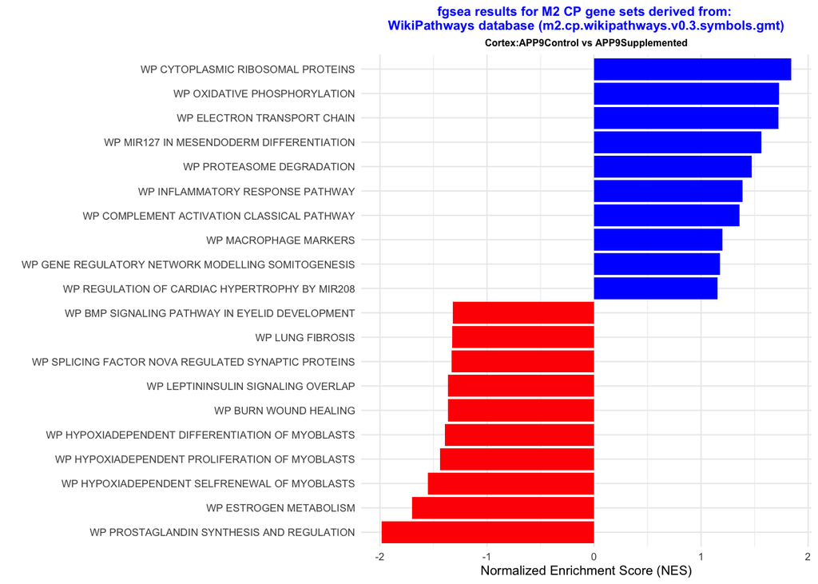

```
## # A tibble: 33,271 × 8
##    genes              volc_plot_sta…¹ log2F…²  padj baseM…³ lfcSE    stat pvalue
##    <chr>              <chr>             <dbl> <dbl>   <dbl> <dbl>   <dbl>  <dbl>
##  1 ENSMUSG00000102628 NS              -0.257      1 4.93e+0 0.667 -0.385   0.700
##  2 ENSMUSG00000086053 NS               1.71       1 1.29e+0 1.67   1.02    0.306
##  3 ENSMUSG00000102135 NS               2.19       1 2.60e-1 4.96   0.442   0.658
##  4 ENSMUSG00000100764 NS               0.301      1 7.79e+0 0.674  0.446   0.656
##  5 ENSMUSG00000100635 NS               0.811      1 1.06e+1 0.970  0.836   0.403
##  6 ENSMUSG00000100480 NS               0.0692     1 4.09e+1 0.334  0.207   0.836
##  7 ENSMUSG00000100025 NS              -0.412      1 9.76e+0 0.495 -0.833   0.405
##  8 ENSMUSG00000051285 NS               0.0102     1 7.47e+3 0.225  0.0455  0.964
##  9 ENSMUSG00000098201 NS               0.615      1 3.29e-1 6.80   0.0904  0.928
## 10 ENSMUSG00000103509 NS              -0.441      1 5.00e+1 0.325 -1.36    0.175
## # … with 33,261 more rows, and abbreviated variable names ¹volc_plot_status,
## #   ²log2FoldChange, ³baseMean
## # ℹ Use `print(n = ...)` to see more rows
```

```
## # A tibble: 190 × 8
##    pathway                        pval  padj log2err     ES    NES  size leadi…¹
##    <chr>                         <dbl> <dbl>   <dbl>  <dbl>  <dbl> <int> <list>
##  1 WP_MIR127_IN_MESENDODERM_DI… 0.0174     1  0.352  -0.839 -1.60      8 <chr>
##  2 WP_LEPTIN_AND_ADIPONECTIN    0.163      1  0.166  -0.651 -1.31     10 <chr>
##  3 WP_NUCLEOTIDE_GPCRS          0.256      1  0.129  -0.574 -1.18     11 <chr>
##  4 WP_TYPE_II_INTERFERON_SIGNA… 0.244      1  0.136  -0.445 -1.15     31 <chr>
##  5 WP_NUCLEAR_RECEPTORS_IN_LIP… 0.383      1  0.106  -0.410 -1.04     28 <chr>
##  6 WP_DISTAL_CONVOLUTED_TUBULE… 0.482      1  0.0889 -0.538 -0.995     7 <chr>
##  7 WP_STEROID_BIOSYNTHESIS      0.581      1  0.0789 -0.469 -0.923     9 <chr>
##  8 WP_TOLLLIKE_RECEPTOR_SIGNAL… 0.549      1  0.0860 -0.354 -0.919    33 <chr>
##  9 WP_MATRIX_METALLOPROTEINASES 0.572      1  0.0834 -0.378 -0.913    24 <chr>
## 10 WP_LEPTININSULIN_SIGNALING_… 0.620      1  0.0763 -0.395 -0.897    17 <chr>
## # … with 180 more rows, and abbreviated variable name ¹leadingEdge
## # ℹ Use `print(n = ...)` to see more rows
```

```
## Hippocampus NES ordered fgsea results saved in file: 'Hippocampus_NES_ordered_fgsea_results_Diet_APP_9_FC0.csv'
```

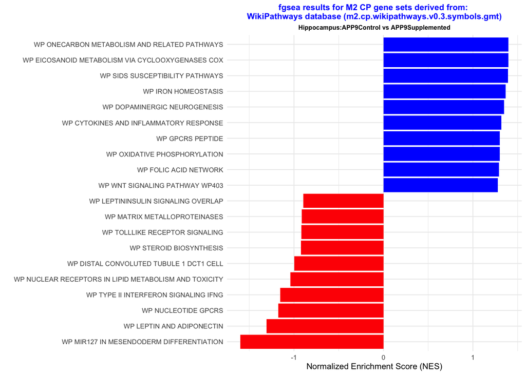